# hw5.Rmd

Sonya Haan

1. Load data

```r
if (file.exists("alcohol.rds")) {
  data <- readRDS("alcohol.rds")
} else {
  url <- "https://xdaiisu.github.io/ds202materials/data/ames.csv"
  data <- readr::read_csv(url)
  saveRDS(data, file="alcohol.rds")
}
```

2. Data cleaning

```r
library(tidyverse)
```

```r
library(ggplot2)
library(lubridate)
data <- data %>% separate(`Store Location`, into=c('Store Address', 'Store City and ZIP', 'Geographic Location (Latitude, Longitude)'), sep='\n')
data <- data %>% select(-`Store City and ZIP`)

data <- data %>% separate(`Geographic Location (Latitude, Longitude)`, into=c('Latitude','Longitude'), sep=", ") %>% mutate('Latitude'=substring(Latitude, 2), 'Longitude'=substr(Longitude, 1, nchar(Longitude)-1))
```

`Store Location` contains 3 different pieces of information, so we separate it into 3 different columns. We can drop the second column (`Store City and ZIP`) as it is redundant information. The store’s geographical location is stored in the `Geographic Location (Latitude, Longitude)` column. We can further split `Geographic Location (Latitude, Longitude)` into separate `Latitude` and `Longitude` columns.

```r
summary(data)
```

```
##  Invoice/Item Number     Date            Store Number   Store Name
##  Length:382033       Length:382033      Min.   :2500   Length:382033
##  Class :character    Class :character   1st Qu.:2501   Class :character
##  Mode  :character    Mode  :character   Median :4004   Mode  :character
##                                         Mean   :3545
##                                         3rd Qu.:4129
##                                         Max.   :5709
##
##    Address              City              Zip Code     Store Address
##  Length:382033      Length:382033      Min.   :50010   Length:382033
##  Class :character   Class :character   1st Qu.:50010   Class :character
##  Mode  :character   Mode  :character   Median :50010   Mode  :character
##                                        Mean   :50010
##                                        3rd Qu.:50010
##                                        Max.   :50015
##
##    Latitude          Longitude         County Number    County
##  Length:382033      Length:382033      Min.   :85    Length:382033
##  Class :character   Class :character   1st Qu.:85    Class :character
##  Mode  :character   Mode  :character   Median :85    Mode  :character
##                                        Mean   :85
##                                        3rd Qu.:85
##                                        Max.   :85
##
##     Category       Category Name      Vendor Number
##  Min.   :1011100   Length:382033      Length:382033
##  1st Qu.:1012300   Class :character   Class :character
##  Median :1031200   Mode  :character   Mode  :character
##  Mean   :1046077
##  3rd Qu.:1062310
##  Max.   :1901200
##  NA's   :437
##  Vendor Name         Item Number     Item Description        Pack
##  Length:382033      Min.   :   115   Length:382033      Min.   :  1.00
##  Class :character   1st Qu.: 27410   Class :character   1st Qu.:  6.00
##  Mode  :character   Median : 39825   Mode  :character   Median : 12.00
##                     Mean   : 49180                      Mean   : 11.59
##                     3rd Qu.: 64636                      3rd Qu.: 12.00
##                     Max.   :995760                      Max.   :288.00
##
```

[output cut: 9 more lines]

```
##  Min.   :   1.000   Min.   :    0.00   Min.   :   0.000
##  1st Qu.:   2.000   1st Qu.:   33.21   1st Qu.:   1.500
##  Median :   6.000   Median :   70.92   Median :   4.500
##  Mean   :   9.317   Mean   :  131.09   Mean   :   9.137
##  3rd Qu.:  12.000   3rd Qu.:  141.72   3rd Qu.:  10.500
##  Max.   :1800.000   Max.   :28350.00   Max.   :2152.500
##                     NA's   :1
##  Volume Sold (Gallons)
##  Min.   :  0.000
##  1st Qu.:  0.400
##  Median :  1.190
##  Mean   :  2.414
##  3rd Qu.:  2.770
##  Max.   :568.630
##
```

```r
data$Date <- mdy(data$Date)
data$`Store Name` <- factor(data$`Store Name`)
data$Latitude <- as.numeric(data$Latitude)
data$Longitude <- as.numeric(data$Longitude)
data$`Category Name` <- factor(data$`Category Name`)
data$`Vendor Name` <- factor(data$`Vendor Name`)
```

Convert variables to appropriate type.

```r
data <- data %>% mutate('Year'=year(Date), 'Month'=month(Date), 'Day'=day(Date))
```

Extract year, month, and day from the variable `Date` and store them in their own columns.

3. First overview

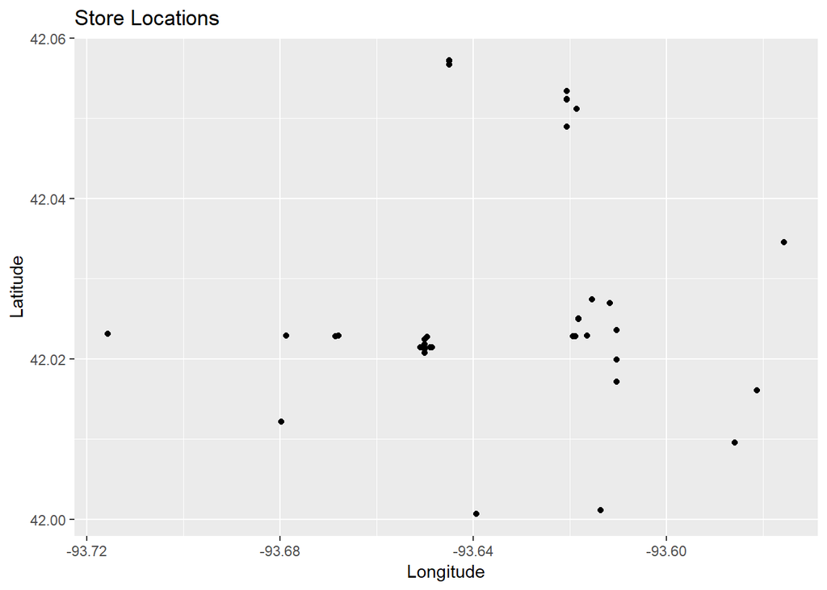

```r
data %>% ggplot(aes(x=Longitude, y=Latitude)) + geom_point() + ggtitle('Store Locations')
```

[figure not shown]

```r
data %>% ggplot(aes(x=`Category Name`, y=`Volume Sold (Liters)`)) + geom_boxplot() + facet_wrap(~`Category Name`)
```

Visualizing the volume sold of of liquor categories at once is difficult because there are 124 categories! Create separate visualizations comparing liquor categories of the same type (vodkas, rums, gins, etc).

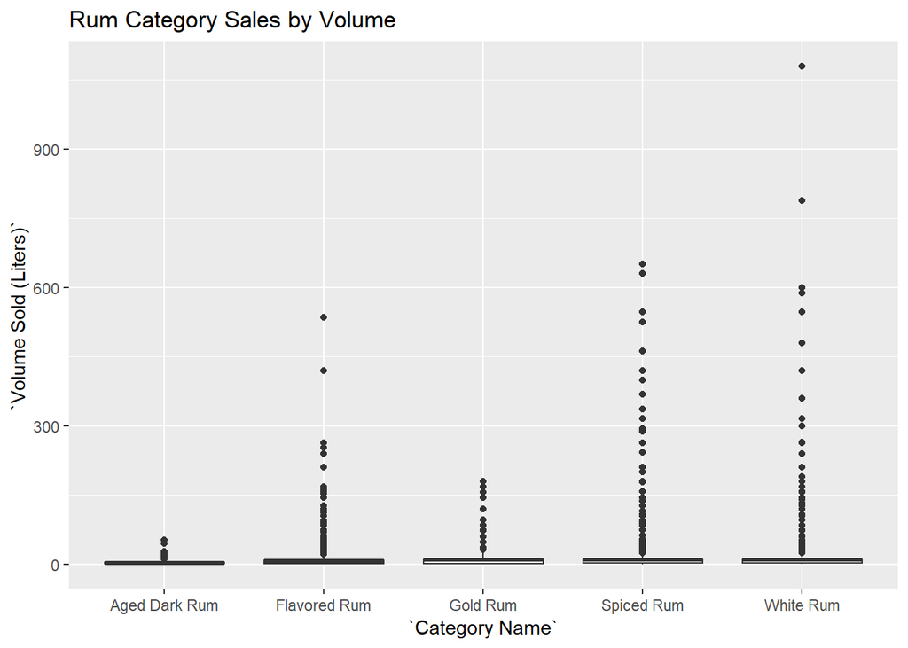

```r
library(stringr)
rum <- data %>% filter(str_detect(`Category Name`, 'Rum'))
rum %>% ggplot(aes(x=`Category Name`, y=`Volume Sold (Liters)`)) + geom_boxplot() + ggtitle('Rum Category Sales by Volume')
```

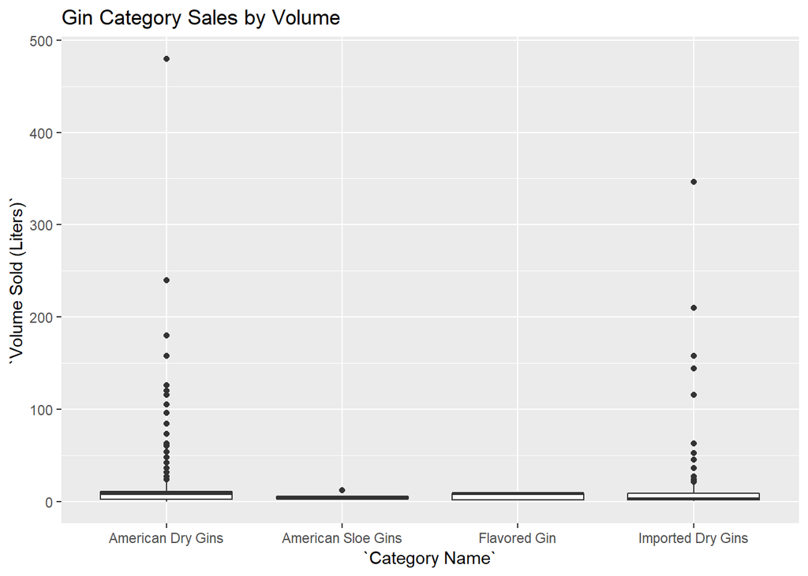

```r
gin <- data %>% filter(str_detect(`Category Name`, 'Gin|Gins'))
gin %>% ggplot(aes(x=`Category Name` ,y=`Volume Sold (Liters)`)) + geom_boxplot() + ggtitle('Gin Category Sales by Volume')
```

[figure not shown]

```r
vodka <- data %>% filter(str_detect(`Category Name`, 'Vodka|Vodkas'))
vodka %>% ggplot(aes(x=`Volume Sold (Liters)` ,y=`Category Name`)) + geom_boxplot() + ggtitle('Vodka Category Sales by Volume')
```

4. Find the daily sales liquor sales in Ames in 2018

```r
ames2018 <- data %>% filter(Year==2018)
ames2018 %>% group_by(Month, Day)  %>% summarize(
          numSales = n(),
          volSold = sum(`Volume Sold (Liters)`, na.rm = TRUE),
          moneySpent = sum(`Sale (Dollars)`, na.rm = TRUE)
)
```

```
## # A tibble: 146 x 5
## # Groups:   Month [?]
##    Month   Day numSales  volSold moneySpent
##    <dbl> <int>    <int>    <dbl>      <dbl>
##  1     1     3      859  6596.     104862.
##  2     1     5      227  1966.      31048.
##  3     1    10     1028 10250.     141905.
##  4     1    12      147  1347.      17881.
##  5     1    17     1309 10196.     159217.
##  6     1    18        1     0.75       11.2
##  7     1    19      151  1148.      15664.
##  8     1    22        1     2.25        0
##  9     1    24     1137  8273.     124823.
## 10     1    25        1     0.75       20.8
## # ... with 136 more rows
```

Find the daily sales liquor sales in Ames in 2018. Summarize number of sales, volume of liquor sold and amount of money spent.

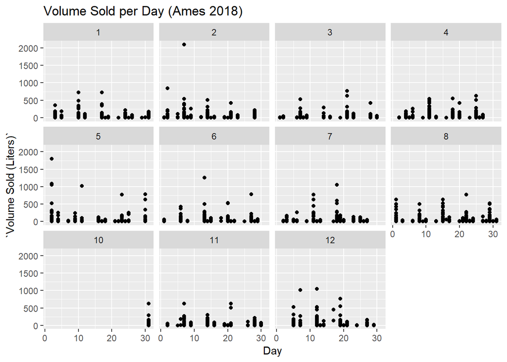

```r
ames2018 %>% ggplot(aes(x=Day, y=`Volume Sold (Liters)`)) + geom_point() + facet_wrap(~Month) + ggtitle('Volume Sold per Day (Ames 2018)')
```

The first thing I noticed was that the data does not appear to be collected every day – some days in the scatterplots have no data plotted. Besides that, the scatterplots show days where the volume sold spikes, which after comparing these spikes to a 2018 calendar, corresponded to Wednesdays. (This is not what I would have expected, I thought weekends would be the days with highest volumes.)

Most ISU home football games occured in September and October, and unfortunately this data is missing. November 10th, November 24th, and December 1st are dates of ISU home football games which we have data for (at least the days surrounding these games because the data does not appear to be collected every day). It appears that a few days before the two November games, volumes were slightly higher, though a significant pattern is not evident.